# Generating Data

Statistical Programming with R

## Topics

- Drawing data from distributions
- Sampling, random seed, pseudo-random number generator

## Packages and functions that we use

```r
library(mvtnorm)  # Multivariate Normal tools
```

- `table()`: Build a contingency table out of counts
- `hist()`: Draw a histogram
- `mvtnorm::rmvnorm()`: Drawing values from a multivariate normal distribution
- `sample()`: Probabilistic sampling with or without replacement
- `rchisq()`: Probabilistic sampling from a \(\chi^2\) distribution
- `rpois()`: Probabilistic sampling from a poisson distribution
- `set.seed(123)`: Fixing the Random Number Generator seed

## Creating our own data

We saw that we could create vectors

```r
c(1, 2, 3, 4, 3, 2, 1)
```

```
## [1] 1 2 3 4 3 2 1
```

```r
c(1:4, 3:1)
```

```
## [1] 1 2 3 4 3 2 1
```

We could create matrices

```r
matrix(1:15, nrow = 3, ncol = 5, byrow = TRUE)
```

```
##      [,1] [,2] [,3] [,4] [,5]
## [1,]    1    2    3    4    5
## [2,]    6    7    8    9   10
## [3,]   11   12   13   14   15
```

## Creating our own data

Create a vector from a matrix:

```r
mat <- matrix(data=1:18, nrow=3, ncol=6)
mat
```

```
##      [,1] [,2] [,3] [,4] [,5] [,6]
## [1,]    1    4    7   10   13   16
## [2,]    2    5    8   11   14   17
## [3,]    3    6    9   12   15   18
```

```r
c(mat)
```

```
##  [1]  1  2  3  4  5  6  7  8  9 10 11 12 13 14 15 16 17 18
```

## But we can also draw a sample

Of the same size,

```r
sample(x=mat)
```

```
##  [1] 15  7 16 11  4 13  9  6  8 10  3 12 17  5 18 14  2  1
```

```r
# Besides x=mat, no other arguments are specified, therefore the function uses
# the defaults:
# If size is not specified, size = number of elements in x
# replace: default value is FALSE
```

smaller size,

```r
sample(mat, size = 5)
```

```
## [1] 15  5  9 18 16
```

or larger size

```r
sample(mat, size = 50, replace = TRUE)
```

```
##  [1] 10 15 13  3 16 14 14 10 14  8 12  7 12 10 18  1 11  7  3  6 17  9 13  8  6
## [26]  8 14 15 15  2  1 16 12  1 17  8 11  4 11  1  4 11 11  1 10 17  4  6 13  7
```

## We can do random sampling

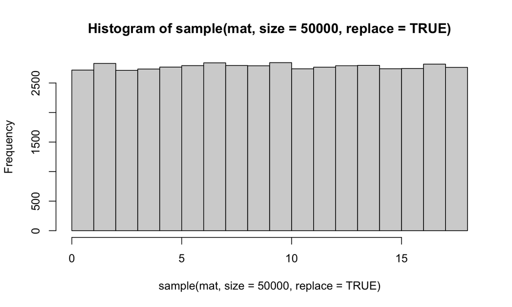

```r
hist(sample(mat, size = 50000, replace=TRUE), breaks = 0:18)
```

## Or nonrandom sampling

```r
probs <- c(rep(.01, 15), .1, .25, .50)
probs
```

```
##  [1] 0.01 0.01 0.01 0.01 0.01 0.01 0.01 0.01 0.01 0.01 0.01 0.01 0.01 0.01 0.01
## [16] 0.10 0.25 0.50
```

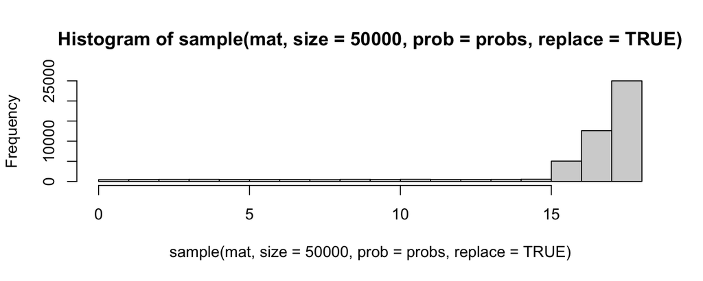

```r
hist(sample(mat, size = 50000, prob = probs, replace=TRUE), breaks = 0:18)
```

## We can replicate individual samples

```r
set.seed(123)
sample(mat, size = 50, replace = TRUE)
```

```
##  [1] 15 14  3 10 18 11  5 14  5  9  3  8  7 10  9  4 14 17 11  7 12 15 10 13  7
## [26]  9  9 10  7  6  2  5  8 12 13 18  1  6 15  9 15 16  6 11  8  7 16 17 18 17
```

```r
set.seed(123)
sample(mat, size = 50, replace = TRUE)
```

```
##  [1] 15 14  3 10 18 11  5 14  5  9  3  8  7 10  9  4 14 17 11  7 12 15 10 13  7
## [26]  9  9 10  7  6  2  5  8 12 13 18  1  6 15  9 15 16  6 11  8  7 16 17 18 17
```

## We can replicate a chain of samples

```r
set.seed(123)
sample(mat, size = 5, replace = TRUE)
```

```
## [1] 15 14  3 10 18
```

```r
sample(mat, size = 7, replace = TRUE)
```

```
## [1] 11  5 14  5  9  3  8
```

```r
set.seed(123)
sample(mat, size = 5, replace = TRUE)
```

```
## [1] 15 14  3 10 18
```

```r
sample(mat, size = 7, replace = TRUE)
```

```
## [1] 11  5 14  5  9  3  8
```

## The random seed, pseudo-random numbers

The random seed is a number used to initialize the pseudo-random number generator

If replication is needed, pseudo-random number generators must be used

- Pseudo-random number generators generate a sequence of numbers determined by an initial value
- The properties of generated number sequences approximates the properties of random number sequences
- But the sequence is predictable and therefore not truly random

## The random seed, pseudo-random numbers

For truly random numbers, visit https://www.random.org/ (random numbers are generated based on atmosperic noise)

The initial value (the seed) itself does not need to be random.

- The resulting process is (pseudo-)random because the seed value is not used to generate randomness
- It merely forms the starting point of the algorithm.

## Why fix the random seed

When an `R` instance is started, there is initially no seed. In that case, `R` will create one from the current time and process ID.

- Hence, different sessions will give different results when random numbers are involved.
- When you store a workspace and reopen it, you will continue from the seed specified within the workspace.

*If we fix the random seed we can exactly replicate the random process*

`If the method has not changed:` the results of the process will be identical when using the same seed.

- Replications allow for verification
- But beware: the process depends on the seed
  - The results obtained could theoretically be extremely rare and would not have occurred with every other potential seed
  - Run another seed before publishing your results

## Random seeds

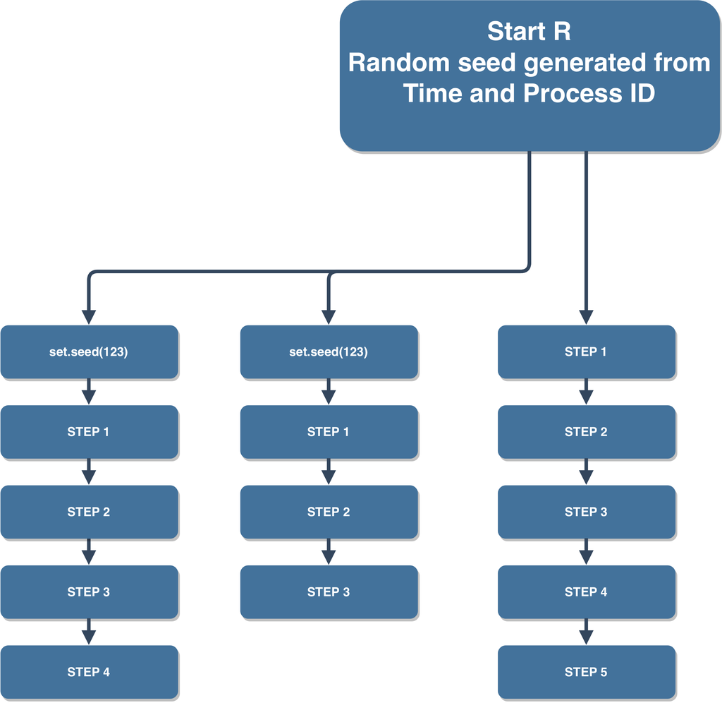

## Drawing data

We can draw data from a standard normal distribution

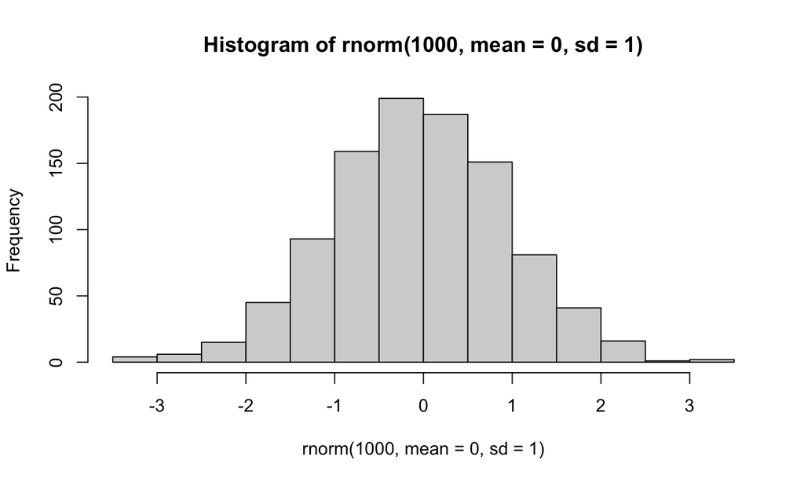

```r
hist(rnorm(1000, mean = 0, sd = 1))
```

## Drawing data

We can draw data from a specific normal distribution

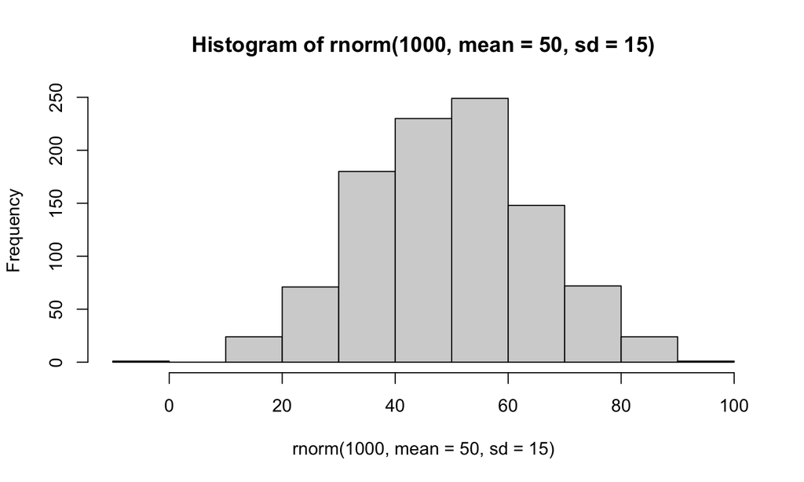

```r
hist(rnorm(1000, mean = 50, sd = 15))
```

## Drawing data: many values

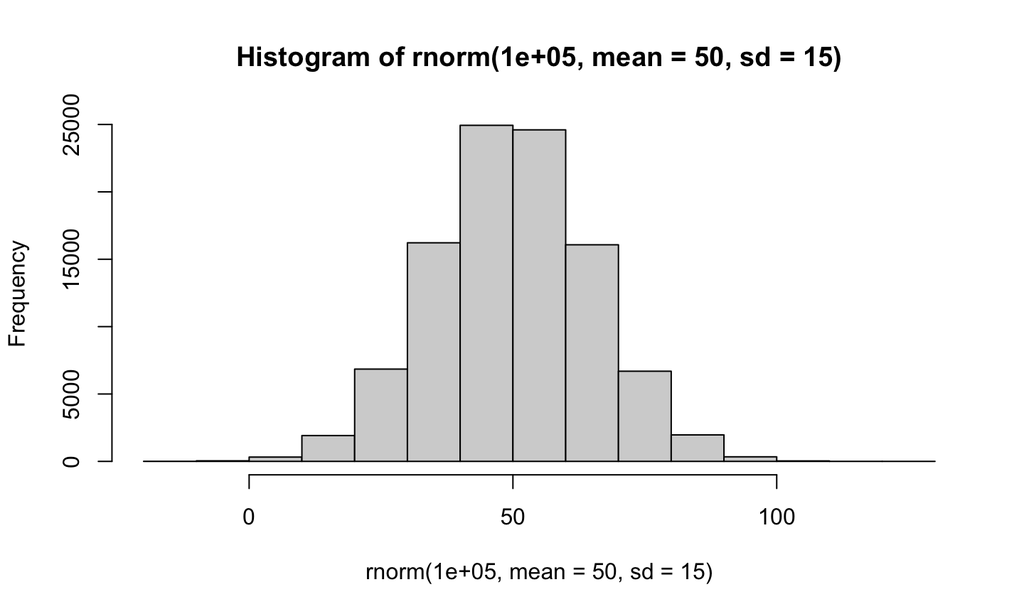

```r
hist(rnorm(100000, mean = 50, sd = 15))
```

## Drawing data: other distribution

\(\chi^2\)-distribution with \(df = 1\) degrees of freedom

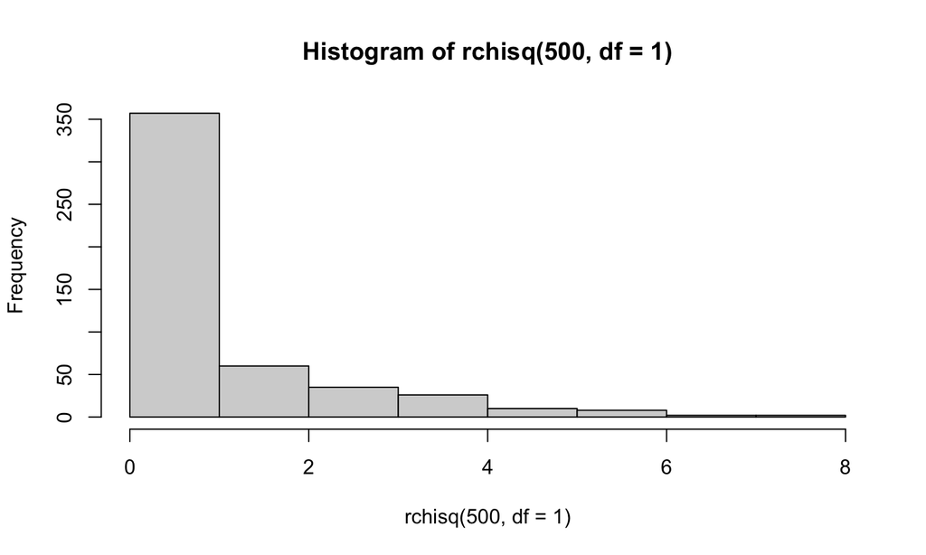

```r
hist(rchisq(500, df = 1))
```

## Drawing data: other distribution

\(\chi^2\)-distribution with \(df = 100\) degrees of freedom

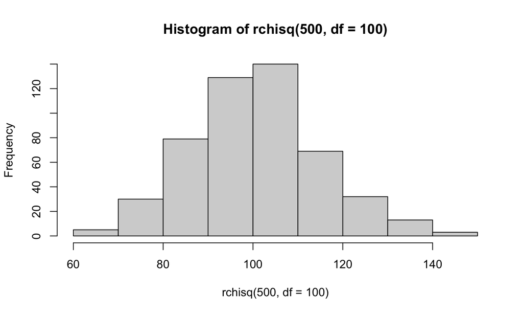

```r
hist(rchisq(500, df = 100))
```

## Drawing data: other distribution

Poisson distribution with mean \(\lambda = 1\)

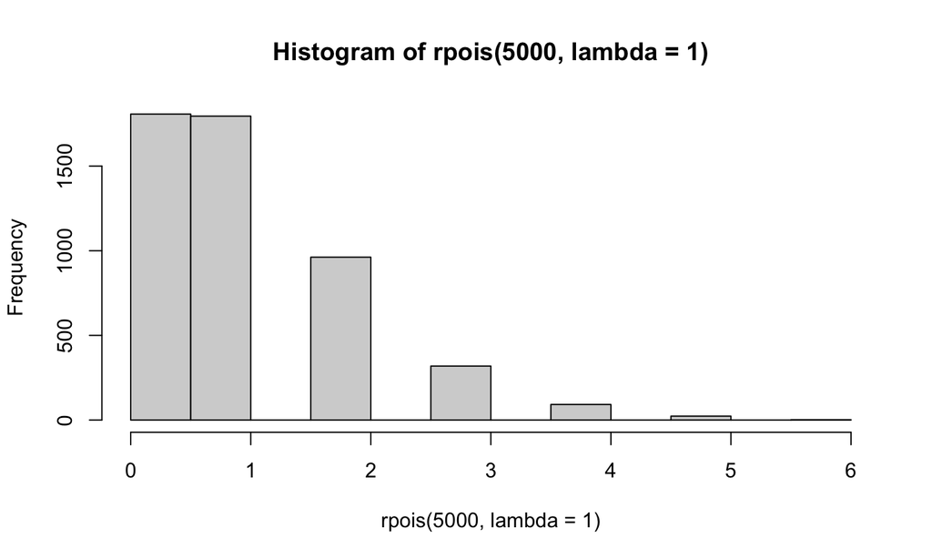

```r
hist(rpois(5000, lambda = 1))
```

## Drawing data: other distribution

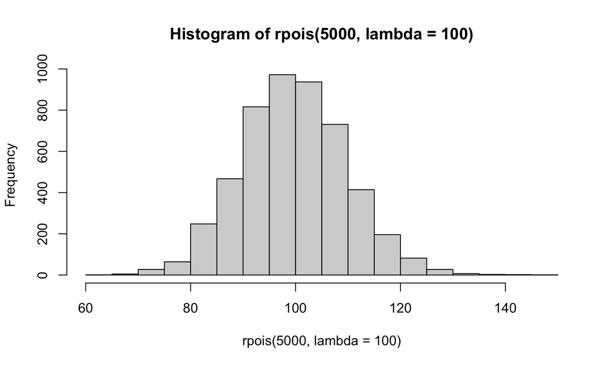

```r
hist(rpois(5000, lambda = 100))
```

## Drawing data: other distribution

Binomial distribution: 1000 draws of 1 trial with \(P(\text{success}=.75)\)

```r
run <- rbinom(1000, size = 1, prob = .75)
table(run)
```

```
## run
##   0   1
## 247 753
```

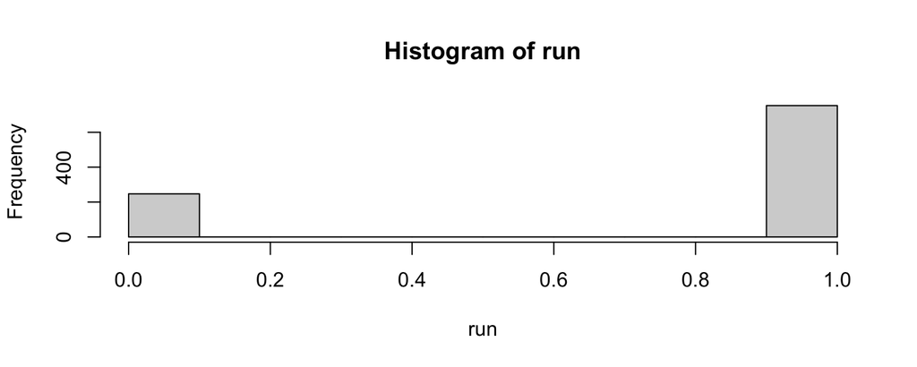

## Drawing data: other distribution

Binomial distribution: 10.000 draws of 60 trials with \(P(\text{success}=.75)\)

```r
run <- rbinom(10000, size = 60, prob = .75)
table(run)
```

```
## run
##   32   33   34   35   36   37   38   39   40   41   42   43   44   45   46   47
##    1    7   10   21   29   67  137  257  395  615  783  981 1096 1195 1136 1053
##   48   49   50   51   52   53   54   55   56
##  836  572  376  200  136   63   25    7    2
```

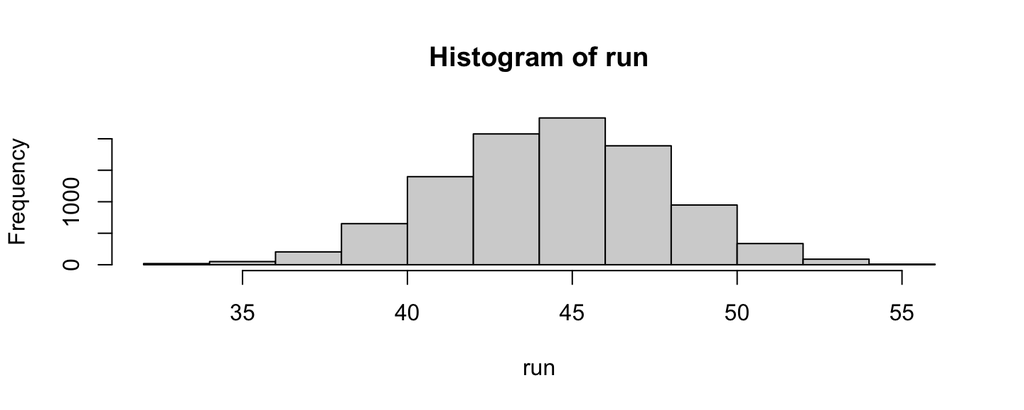

## Drawing multivariate distributions

```r
sigma <- matrix(c(30, 15, 15, 30), 2, 2)
sigma
```

```
##      [,1] [,2]
## [1,]   30   15
## [2,]   15   30
```

```r
means <- c(97, 63)
data <- rmvnorm(n = 1000, mean = means, sigma = sigma)
colMeans(data)
```

```
## [1] 96.86905 62.77418
```

```r
var(data)
```

```
##          [,1]     [,2]
## [1,] 26.98297 14.28588
## [2,] 14.28588 31.07523
```

## Bivariate normal

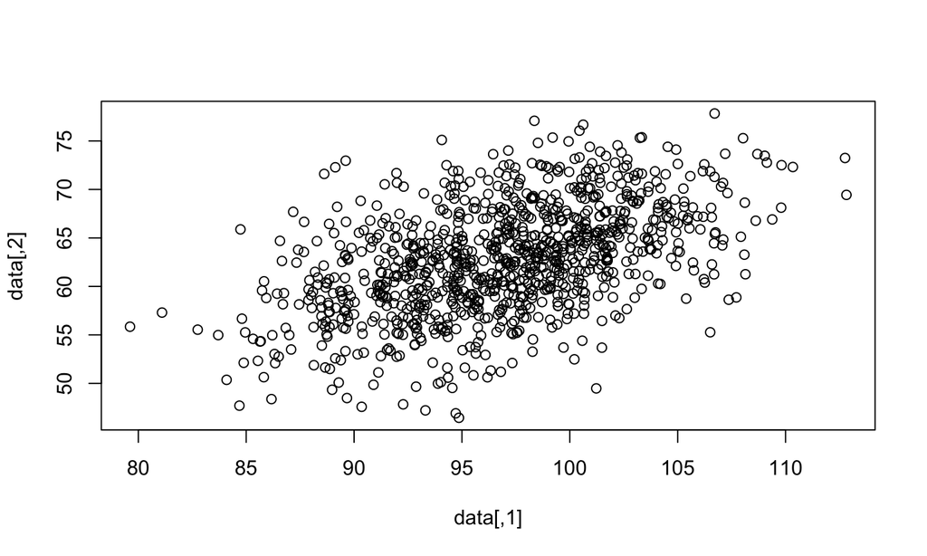

```r
plot(data)
```

## Drawing multivariate distributions

```r
sigma <- matrix(c(1, 0, 0, 1), 2, 2)
sigma
```

```
##      [,1] [,2]
## [1,]    1    0
## [2,]    0    1
```

```r
means <- c(0, 0)
data <- rmvnorm(n = 1000, mean = means, sigma = sigma)
colMeans(data)
```

```
## [1] -0.004211069  0.007496766
```

```r
var(data)
```

```
##              [,1]         [,2]
## [1,]  0.869919122 -0.002239893
## [2,] -0.002239893  1.074986477
```

## Bivariate normal

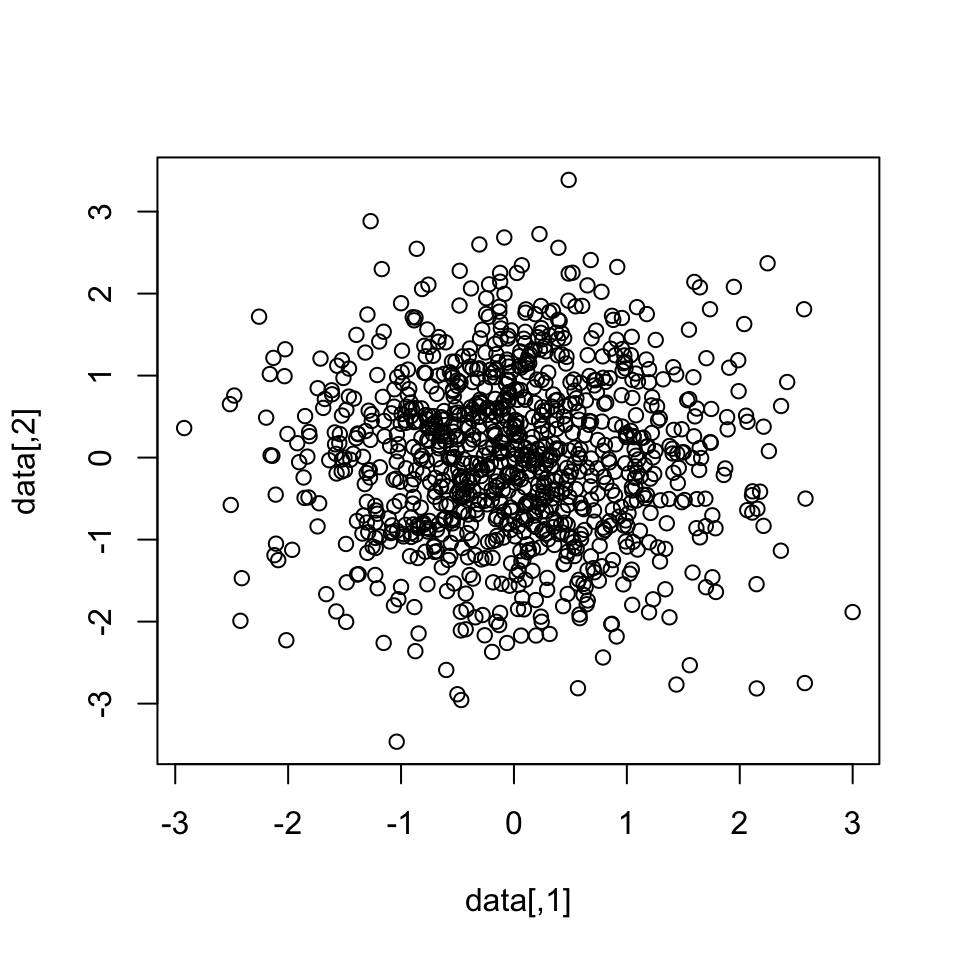

```r
plot(data)
```

## Histograms

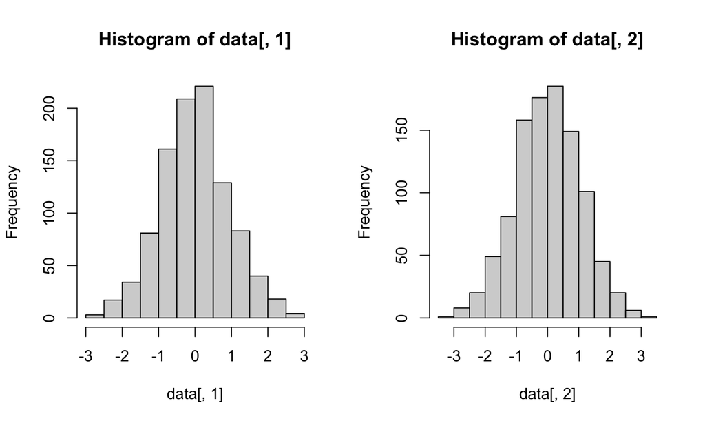

```r
par(mfrow = c(1, 2))
hist(data[, 1])
hist(data[, 2])
```

## Practical

## Practical B

- Open the `Practical B Solutions` file to check the answers.
- Open the `Practical B Template` file to write the code.